# Ensemble Project - Term Sale Deposit

```python
# Droping Target

NewBankData = BankData.drop(labels = 'Target',axis=1)
NewBankData.head()
```

|  | age | job | marital | education | default | balance | housing | loan | contact | day | month | duration | campaign | pdays | previous | poutcome |
| --- | --- | --- | --- | --- | --- | --- | --- | --- | --- | --- | --- | --- | --- | --- | --- | --- |
| 0 | 58 | management | married | tertiary | no | 2143 | yes | no | unknown | 5 | may | 261 | 1 | -1 | 0 | unknown |
| 1 | 44 | technician | single | secondary | no | 29 | yes | no | unknown | 5 | may | 151 | 1 | -1 | 0 | unknown |
| 2 | 33 | entrepreneur | married | secondary | no | 2 | yes | yes | unknown | 5 | may | 76 | 1 | -1 | 0 | unknown |
| 3 | 47 | blue-collar | married | unknown | no | 1506 | yes | no | unknown | 5 | may | 92 | 1 | -1 | 0 | unknown |
| 4 | 33 | unknown | single | unknown | no | 1 | no | no | unknown | 5 | may | 198 | 1 | -1 | 0 | unknown |

```python
NewBankData = pd.get_dummies(NewBankData)
NewBankData
```

|  | age | balance | duration | campaign | pdays | previous | job_admin. | job_blue-collar | job_entrepreneur | job_housemaid | ... | month_jun | month_mar | month_may | month_nov | month_oct | month_sep | poutcome_failure | poutcome_other | poutcome_success | poutcome_unknown |
| --- | --- | --- | --- | --- | --- | --- | --- | --- | --- | --- | --- | --- | --- | --- | --- | --- | --- | --- | --- | --- | --- |
| 0 | 58 | 2143 | 261 | 1 | -1 | 0 | 0 | 0 | 0 | 0 | ... | 0 | 0 | 1 | 0 | 0 | 0 | 0 | 0 | 0 | 1 |
| 1 | 44 | 29 | 151 | 1 | -1 | 0 | 0 | 0 | 0 | 0 | ... | 0 | 0 | 1 | 0 | 0 | 0 | 0 | 0 | 0 | 1 |
| 2 | 33 | 2 | 76 | 1 | -1 | 0 | 0 | 0 | 1 | 0 | ... | 0 | 0 | 1 | 0 | 0 | 0 | 0 | 0 | 0 | 1 |
| 3 | 47 | 1506 | 92 | 1 | -1 | 0 | 0 | 1 | 0 | 0 | ... | 0 | 0 | 1 | 0 | 0 | 0 | 0 | 0 | 0 | 1 |
| 4 | 33 | 1 | 198 | 1 | -1 | 0 | 0 | 0 | 0 | 0 | ... | 0 | 0 | 1 | 0 | 0 | 0 | 0 | 0 | 0 | 1 |
| ... | ... | ... | ... | ... | ... | ... | ... | ... | ... | ... | ... | ... | ... | ... | ... | ... | ... | ... | ... | ... | ... |
| 45206 | 51 | 825 | 977 | 3 | -1 | 0 | 0 | 0 | 0 | 0 | ... | 0 | 0 | 0 | 1 | 0 | 0 | 0 | 0 | 0 | 1 |
| 45207 | 71 | 1729 | 456 | 2 | -1 | 0 | 0 | 0 | 0 | 0 | ... | 0 | 0 | 0 | 1 | 0 | 0 | 0 | 0 | 0 | 1 |
| 45208 | 72 | 5715 | 1127 | 5 | 184 | 3 | 0 | 0 | 0 | 0 | ... | 0 | 0 | 0 | 1 | 0 | 0 | 0 | 0 | 1 | 0 |
| 45209 | 57 | 668 | 508 | 4 | -1 | 0 | 0 | 1 | 0 | 0 | ... | 0 | 0 | 0 | 1 | 0 | 0 | 0 | 0 | 0 | 1 |
| 45210 | 37 | 2971 | 361 | 2 | 188 | 11 | 0 | 0 | 1 | 0 | ... | 0 | 0 | 0 | 1 | 0 | 0 | 0 | 1 | 0 | 0 |

45211 rows × 81 columns

```python
NewBankData.shape
```

```
(45211, 81)
```

```python
NewBankData.dtypes
```

```
age                 int64
balance             int64
duration            int64
campaign            int64
pdays               int64
                    ...
month_sep           uint8
poutcome_failure    uint8
poutcome_other      uint8
poutcome_success    uint8
poutcome_unknown    uint8
Length: 81, dtype: object
```

```python
NewBankData.corr()
```

|  | age | balance | duration | campaign | pdays | previous | job_admin. | job_blue-collar | job_entrepreneur | job_housemaid | ... | month_jun | month_mar | month_may | month_nov | month_oct | month_sep | poutcome_failure | poutcome_other | poutcome_success | poutcome_unknown |
| --- | --- | --- | --- | --- | --- | --- | --- | --- | --- | --- | --- | --- | --- | --- | --- | --- | --- | --- | --- | --- | --- |
| age | 1.000000 | 0.097783 | -0.004648 | 0.004760 | -0.023758 | 0.001288 | -0.055717 | -0.044002 | 0.021792 | 0.086650 | ... | 0.051768 | 0.019499 | -0.127431 | 0.032775 | 0.060116 | 0.032418 | -0.004927 | -0.022967 | 0.035526 | -0.000816 |
| balance | 0.097783 | 1.000000 | 0.021560 | -0.014578 | 0.003435 | 0.016674 | -0.026726 | -0.048757 | 0.009642 | 0.001661 | ... | 0.029566 | 0.023196 | -0.071121 | 0.117254 | 0.040198 | 0.021922 | 0.011857 | 0.008466 | 0.035240 | -0.030271 |
| duration | -0.004648 | 0.021560 | 1.000000 | -0.084570 | -0.001565 | 0.001203 | -0.015722 | 0.009637 | -0.001327 | -0.008046 | ... | -0.021426 | -0.005519 | 0.007089 | -0.006041 | 0.015076 | 0.015077 | -0.018925 | -0.001958 | 0.042389 | -0.003491 |
| campaign | 0.004760 | -0.014578 | -0.084570 | 1.000000 | -0.088628 | -0.032855 | -0.021868 | 0.008986 | 0.002128 | 0.003097 | ... | 0.043893 | -0.018612 | -0.067551 | -0.084697 | -0.051031 | -0.036718 | -0.088131 | -0.020107 | -0.057486 | 0.107965 |
| pdays | -0.023758 | 0.003435 | -0.001565 | -0.088628 | 1.000000 | 0.454820 | 0.027497 | 0.020063 | -0.014203 | -0.031350 | ... | -0.113476 | 0.032002 | 0.079029 | 0.007892 | 0.056814 | 0.084427 | 0.701052 | 0.389791 | 0.228539 | -0.869962 |
| ... | ... | ... | ... | ... | ... | ... | ... | ... | ... | ... | ... | ... | ... | ... | ... | ... | ... | ... | ... | ... | ... |
| month_sep | 0.032418 | 0.021922 | 0.015077 | -0.036718 | 0.084427 | 0.064990 | 0.007279 | -0.044816 | -0.007769 | -0.002265 | ... | -0.041687 | -0.011761 | -0.075361 | -0.035338 | -0.014672 | 1.000000 | 0.036215 | 0.037270 | 0.123293 | -0.105580 |
| poutcome_failure | -0.004927 | 0.011857 | -0.018925 | -0.088131 | 0.701052 | 0.350627 | 0.018431 | 0.002254 | 0.001119 | -0.016300 | ... | -0.098305 | 0.016219 | 0.030105 | 0.092167 | 0.037617 | 0.036215 | 1.000000 | -0.071820 | -0.064838 | -0.737932 |
| poutcome_other | -0.022967 | 0.008466 | -0.001958 | -0.020107 | 0.389791 | 0.306615 | 0.010745 | 0.001342 | -0.013506 | -0.016769 | ... | -0.051110 | 0.020364 | 0.007480 | 0.019946 | 0.027354 | 0.037270 | -0.071820 | 1.000000 | -0.038300 | -0.435903 |
| poutcome_success | 0.035526 | 0.035240 | 0.042389 | -0.057486 | 0.228539 | 0.201424 | 0.012056 | -0.053074 | -0.019111 | -0.009375 | ... | -0.023068 | 0.053066 | -0.059922 | 0.003617 | 0.103269 | 0.123293 | -0.064838 | -0.038300 | 1.000000 | -0.393525 |
| poutcome_unknown | -0.000816 | -0.030271 | -0.003491 | 0.107965 | -0.869962 | -0.532763 | -0.025940 | 0.022194 | 0.014901 | 0.026059 | ... | 0.115997 | -0.048162 | -0.000175 | -0.086066 | -0.092320 | -0.105580 | -0.737932 | -0.435903 | -0.393525 | 1.000000 |

81 rows × 81 columns

### Split the data into training and test set in the ratio of 70:30

```python
#Create Training/Testing set in ratio 70:30

from sklearn.model_selection import train_test_split

BankData_X = NewBankData     #Predictor columns
BankData_Y = BankData['Target']  #Predicted Target

BankData_X_train, BankData_X_test, BankData_Y_train, BankData_Y_test = train_test_split(BankData_X, BankData_Y, test_size = 0.3, random_state =1)

BankData_X_train.head()
```

|  | age | balance | duration | campaign | pdays | previous | job_admin. | job_blue-collar | job_entrepreneur | job_housemaid | ... | month_jun | month_mar | month_may | month_nov | month_oct | month_sep | poutcome_failure | poutcome_other | poutcome_success | poutcome_unknown |
| --- | --- | --- | --- | --- | --- | --- | --- | --- | --- | --- | --- | --- | --- | --- | --- | --- | --- | --- | --- | --- | --- |
| 6149 | 32 | -238 | 427 | 1 | -1 | 0 | 0 | 1 | 0 | 0 | ... | 0 | 0 | 1 | 0 | 0 | 0 | 0 | 0 | 0 | 1 |
| 12403 | 34 | -478 | 111 | 4 | -1 | 0 | 1 | 0 | 0 | 0 | ... | 1 | 0 | 0 | 0 | 0 | 0 | 0 | 0 | 0 | 1 |
| 21645 | 32 | 266 | 168 | 2 | -1 | 0 | 0 | 0 | 0 | 0 | ... | 0 | 0 | 0 | 0 | 0 | 0 | 0 | 0 | 0 | 1 |
| 29580 | 36 | 13 | 150 | 4 | -1 | 0 | 0 | 1 | 0 | 0 | ... | 0 | 0 | 0 | 0 | 0 | 0 | 0 | 0 | 0 | 1 |
| 31245 | 23 | 486 | 87 | 1 | -1 | 0 | 0 | 0 | 0 | 0 | ... | 0 | 1 | 0 | 0 | 0 | 0 | 0 | 0 | 0 | 1 |

5 rows × 81 columns

```python
BankData_Y_test.value_counts()
```

```
0    12013
1     1551
Name: Target, dtype: int64
```

### Model - Logistic Regression

```python
#Classification algorithm - Logistic Regression

from sklearn import metrics
from sklearn.linear_model import LogisticRegression
print("************************* Parameters of Logistic Regression ********************************")
print()
print(LogisticRegression())    #printing the parameters of LogisticRegression()


print("*********************************************************************************************")
#Fit the model on train

LR_model = LogisticRegression(solver = "liblinear")  #assigning a variable for the algorithm

LR_model.fit(BankData_X_train, BankData_Y_train) #training of model

LR_model_Y_predict = LR_model.predict(BankData_X_test)     #model is predicting y values based on test dataset given to the model

coef_df = pd.DataFrame(LR_model.coef_)
coef_df['intercept'] = LR_model.intercept_
print(coef_df)

print('*************************************************************************************************')

print("Training accuracy  = ",LR_model.score(BankData_X_train, BankData_Y_train))  # this will give training accuracy as training data has been used
print()
print("Testing accuracy   = ",LR_model.score(BankData_X_test, BankData_Y_test))   # this will give testing accuracy as testing data has been used
```

```
************************* Parameters of Logistic Regression ********************************

LogisticRegression(C=1.0, class_weight=None, dual=False, fit_intercept=True,
                   intercept_scaling=1, l1_ratio=None, max_iter=100,
                   multi_class='auto', n_jobs=None, penalty='l2',
                   random_state=None, solver='lbfgs', tol=0.0001, verbose=0,
                   warm_start=False)
          0         1         2        3         4         5         6  \
0 -0.003781  0.000016  0.004333 -0.08578  0.000002  0.024073  0.077875

          7         8         9  ...        72        73        74        75  \
0 -0.203628 -0.397137 -0.349226  ...  1.255099 -0.570603 -0.721945  0.944304

         76        77        78        79        80  intercept
0  0.784489 -0.724272 -0.643806  1.411497 -0.783601  -0.740181

[1 rows x 82 columns]
Training accuracy  =  0.9028343918854868

Testing accuracy   =  0.9023886759068122
```

```python
#Creating Confusion metrics - Logistic Regression

from sklearn.metrics import confusion_matrix, recall_score, precision_score, f1_score, roc_auc_score, roc_curve,auc

## importing necessary metrics to evaluate model performance

## function to get confusion matrix in a proper format
def draw_cm( actual, predicted ):
    cm = confusion_matrix( actual, predicted)
    sns.heatmap(cm, annot=True,  fmt='.2f', xticklabels = [0,1] , yticklabels = [0,1] )
    plt.ylabel('Observed')
    plt.xlabel('Predicted')
    plt.show()
```

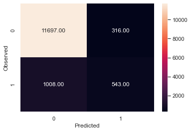

|  | Predict 0 | Predict 1 |
| --- | --- | --- |
| 0 | 11697 | 316 |
| 1 | 1008 | 543 |

```python
df_cm = pd.DataFrame(confusion_matrix(BankData_Y_test, LR_model_Y_predict), index = [i for i in ["0","1"]],
                  columns = [i for i in ["Predict 0","Predict 1"]])


draw_cm(BankData_Y_test, LR_model_Y_predict)

df_cm
```

```python
### Classification Report
```

```python
print("***** Classification Report of Logistic Regression ***** ")
print(metrics.classification_report(BankData_Y_test, LR_model_Y_predict, labels=[1,0]))
```

```
***** Classification Report of Logistic Regression *****
              precision    recall  f1-score   support

           1       0.63      0.35      0.45      1551
           0       0.92      0.97      0.95     12013

    accuracy                           0.90     13564
   macro avg       0.78      0.66      0.70     13564
weighted avg       0.89      0.90      0.89     13564
```

```python
BankData_Y_test.value_counts()
```

```
0    12013
1     1551
Name: Target, dtype: int64
```

```python
precision_score(BankData_Y_test, LR_model_Y_predict)
```

```
0.6321303841676368
```

```python
recall_score(BankData_Y_test, LR_model_Y_predict)
```

```
0.35009671179883944
```

```python
f1_score(BankData_Y_test, LR_model_Y_predict)
```

```
0.4506224066390041
```

```python
roc_auc_score(BankData_Y_test, LR_model_Y_predict)
```

```
0.6618959376858178
```

```python
Data1=[["Logistic Regression",LR_model.score(BankData_X_train, BankData_Y_train),LR_model.score(BankData_X_test, BankData_Y_test),precision_score(BankData_Y_test, LR_model_Y_predict),recall_score(BankData_Y_test, LR_model_Y_predict),f1_score(BankData_Y_test, LR_model_Y_predict),roc_auc_score(BankData_Y_test, LR_model_Y_predict)]]
```

```python
df = pd.DataFrame(Data1,columns = ['Model','Training Score','Testing Score','Precision Score','Recall Score','f1-Score', 'ROC_AUC_Score'])
```

```python
df
```

|  | Model | Training Score | Testing Score | Precision Score | Recall Score | f1-Score | ROC_AUC_Score |
| --- | --- | --- | --- | --- | --- | --- | --- |
| 0 | Logistic Regression | 0.902834 | 0.902389 | 0.63213 | 0.350097 | 0.450622 | 0.661896 |

### Classification algorithm - DECISION TREE

```python
NewBankData.info()
```

```
<class 'pandas.core.frame.DataFrame'>
RangeIndex: 45211 entries, 0 to 45210
Data columns (total 81 columns):
 #   Column               Non-Null Count  Dtype
---  ------               --------------  -----
 0   age                  45211 non-null  int64
 1   balance              45211 non-null  int64
 2   duration             45211 non-null  int64
 3   campaign             45211 non-null  int64
 4   pdays                45211 non-null  int64
 5   previous             45211 non-null  int64
 6   job_admin.           45211 non-null  uint8
 7   job_blue-collar      45211 non-null  uint8
 8   job_entrepreneur     45211 non-null  uint8
 9   job_housemaid        45211 non-null  uint8
```

[output cut: 73 more lines]

```python
BankData_Y_test
```

```
3610     0
11677    0
33018    0
44323    1
8119     0
        ..
10811    0
28752    0
22657    0
12529    0
44850    1
Name: Target, Length: 13564, dtype: int64
```

```python
BankData['Target']
```

```
0        0
1        0
2        0
3        0
4        0
        ..
45206    1
45207    1
45208    1
45209    0
45210    0
Name: Target, Length: 45211, dtype: int64
```

# Split Data

```python
#Classification algorithm - DECISION TREE

BankData_DT_X = NewBankData     # Predictor feature columns (8 X m)
BankData_DT_Y = BankData['Target']   # Predicted class (1=True, 0=False) (1 X m)
BankData_DT_X_train, BankData_DT_X_test, BankData_DT_Y_train, BankData_DT_Y_test = train_test_split(BankData_DT_X, BankData_DT_Y, test_size=0.3, random_state=1)
# 1 is just any random seed number
```

## Building Decision Tree Model - Using 'entropy'

```python
from sklearn.tree import DecisionTreeClassifier
dTree = DecisionTreeClassifier(criterion = 'entropy')
dTree.fit(BankData_DT_X_train, BankData_DT_Y_train)
```

```
DecisionTreeClassifier(ccp_alpha=0.0, class_weight=None, criterion='entropy',
                       max_depth=None, max_features=None, max_leaf_nodes=None,
                       min_impurity_decrease=0.0, min_impurity_split=None,
                       min_samples_leaf=1, min_samples_split=2,
                       min_weight_fraction_leaf=0.0, presort='deprecated',
                       random_state=None, splitter='best')
```

## Scoring Decision Tree

```python
print(dTree.score(BankData_DT_X_train, BankData_DT_Y_train))
print(dTree.score(BankData_DT_X_test, BankData_DT_Y_test))
```

```
1.0
0.8752580359775878
```

```python
print("Training accuracy = ",dTree.score(BankData_X_train, BankData_Y_train))  # this will give training accuracy as training data has been used
print()
print("Testing  accuracy = ",dTree.score(BankData_X_test, BankData_Y_test))   # this will give testing accuracy as testing data has been used
```

```
Training accuracy =  1.0

Testing  accuracy =  0.8752580359775878
```

## Reducing Overfitting

```python
dTreeR = DecisionTreeClassifier(criterion = 'entropy', max_depth = 3, random_state=1)
dTreeR.fit(BankData_DT_X_train, BankData_DT_Y_train)
print(dTreeR.score(BankData_DT_X_train, BankData_DT_Y_train))
print(dTreeR.score(BankData_DT_X_test, BankData_DT_Y_test))
```

```
0.8997693304262647
0.9014302565614863
```

```python
print("Training accuracy = ",dTreeR.score(BankData_X_train, BankData_Y_train))  # this will give training accuracy as training data has been used
print()
print("Testing accuracy  = ",dTreeR.score(BankData_X_test, BankData_Y_test))   # this will give testing accuracy as testing data has been used
```

```
Training accuracy =  0.8997693304262647

Testing accuracy  =  0.9014302565614863
```

## Confusion Matrix

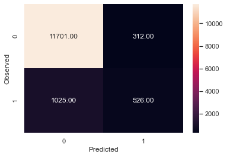

|  | Predict 0 | Predict 1 |
| --- | --- | --- |
| 0 | 11701 | 312 |
| 1 | 1025 | 526 |

```python
DT_Y_predict = dTreeR.predict(BankData_DT_X_test)

df_cm = pd.DataFrame(confusion_matrix(BankData_Y_test, DT_Y_predict), index = [i for i in ["0","1"]],
                  columns = [i for i in ["Predict 0","Predict 1"]])


draw_cm(BankData_Y_test, DT_Y_predict)

df_cm
```

```python
print("***** Classification Report of Decision Tree***** ")
print(metrics.classification_report(BankData_Y_test, DT_Y_predict, labels=[1,0]))
```

```
***** Classification Report of Decision Tree*****
              precision    recall  f1-score   support

           1       0.63      0.34      0.44      1551
           0       0.92      0.97      0.95     12013

    accuracy                           0.90     13564
   macro avg       0.77      0.66      0.69     13564
weighted avg       0.89      0.90      0.89     13564
```

```python
precision_score(BankData_Y_test, DT_Y_predict)
```

```
0.6276849642004774
```

```python
recall_score(BankData_Y_test, DT_Y_predict)
```

```
0.33913604126370084
```

```python
f1_score(BankData_Y_test, DT_Y_predict)
```

```
0.44035161155295105
```

```python
roc_auc_score(BankData_Y_test, DT_Y_predict)
```

```
0.6565820887247498
```

```python
new_row = {'Model':'Decision Tree  entropy','Training Score':dTreeR.score(BankData_DT_X_train, BankData_DT_Y_train),'Testing Score':dTreeR.score(BankData_DT_X_test, BankData_DT_Y_test),'Precision Score':precision_score(BankData_Y_test, DT_Y_predict),'Recall Score':recall_score(BankData_Y_test, DT_Y_predict),'f1-Score':f1_score(BankData_Y_test, DT_Y_predict),'ROC_AUC_Score':roc_auc_score(BankData_Y_test, DT_Y_predict)}
df = df.append(new_row, ignore_index=True)
df
```

|  | Model | Training Score | Testing Score | Precision Score | Recall Score | f1-Score | ROC_AUC_Score |
| --- | --- | --- | --- | --- | --- | --- | --- |
| 0 | Logistic Regression | 0.902834 | 0.902389 | 0.632130 | 0.350097 | 0.450622 | 0.661896 |
| 1 | Decision Tree entropy | 0.899769 | 0.901430 | 0.627685 | 0.339136 | 0.440352 | 0.656582 |

## Building Decision Tree Model - Using 'gini'

```python
from sklearn.tree import DecisionTreeClassifier
dTree = DecisionTreeClassifier(criterion = 'gini')
dTree.fit(BankData_DT_X_train, BankData_DT_Y_train)
```

```
DecisionTreeClassifier(ccp_alpha=0.0, class_weight=None, criterion='gini',
                       max_depth=None, max_features=None, max_leaf_nodes=None,
                       min_impurity_decrease=0.0, min_impurity_split=None,
                       min_samples_leaf=1, min_samples_split=2,
                       min_weight_fraction_leaf=0.0, presort='deprecated',
                       random_state=None, splitter='best')
```

## Scoring Decision Tree

```python
print(dTree.score(BankData_DT_X_train, BankData_DT_Y_train))
print(dTree.score(BankData_DT_X_test, BankData_DT_Y_test))
```

```
1.0
0.8771011501032144
```

```python
print("Training accuracy = ",dTree.score(BankData_X_train, BankData_Y_train))  # this will give training accuracy as training data has been used
print()
print("Testing  accuracy = ",dTree.score(BankData_X_test, BankData_Y_test))   # this will give testing accuracy as testing data has been used
```

```
Training accuracy =  1.0

Testing  accuracy =  0.8771011501032144
```

## Reducing Overfitting

```python
dTreeR = DecisionTreeClassifier(criterion = 'gini', max_depth = 3, random_state=1)
dTreeR.fit(BankData_DT_X_train, BankData_DT_Y_train)
print(dTreeR.score(BankData_DT_X_train, BankData_DT_Y_train))
print(dTreeR.score(BankData_DT_X_test, BankData_DT_Y_test))
```

```
0.9005276961481341
0.9019463285166618
```

```python
print("Training accuracy = ",dTreeR.score(BankData_X_train, BankData_Y_train))  # this will give training accuracy as training data has been used
print()
print("Testing accuracy  = ",dTreeR.score(BankData_X_test, BankData_Y_test))   # this will give testing accuracy as testing data has been used
```

```
Training accuracy =  0.9005276961481341

Testing accuracy  =  0.9019463285166618
```

## Confusion Matrix

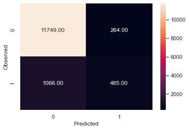

|  | Predict 0 | Predict 1 |
| --- | --- | --- |
| 0 | 11749 | 264 |
| 1 | 1066 | 485 |

```python
DT_Y_predict = dTreeR.predict(BankData_DT_X_test)

df_cm = pd.DataFrame(confusion_matrix(BankData_Y_test, DT_Y_predict), index = [i for i in ["0","1"]],
                  columns = [i for i in ["Predict 0","Predict 1"]])


draw_cm(BankData_Y_test, DT_Y_predict)

df_cm
```

```python
print("***** Classification Report of Decision Tree***** ")
print(metrics.classification_report(BankData_Y_test, DT_Y_predict, labels=[1,0]))
```

```
***** Classification Report of Decision Tree*****
              precision    recall  f1-score   support

           1       0.65      0.31      0.42      1551
           0       0.92      0.98      0.95     12013

    accuracy                           0.90     13564
   macro avg       0.78      0.65      0.68     13564
weighted avg       0.89      0.90      0.89     13564
```

```python
precision_score(BankData_Y_test, DT_Y_predict)
```

```
0.6475300400534045
```

```python
recall_score(BankData_Y_test, DT_Y_predict)
```

```
0.3127014829142489
```

```python
f1_score(BankData_Y_test, DT_Y_predict)
```

```
0.4217391304347826
```

```python
roc_auc_score(BankData_Y_test, DT_Y_predict)
```

```
0.6453626452280393
```

```python
new_row = {'Model':'Decision Tree  gini','Training Score':dTreeR.score(BankData_DT_X_train, BankData_DT_Y_train),'Testing Score':dTreeR.score(BankData_DT_X_test, BankData_DT_Y_test),'Precision Score':precision_score(BankData_Y_test, DT_Y_predict),'Recall Score':recall_score(BankData_Y_test, DT_Y_predict),'f1-Score':f1_score(BankData_Y_test, DT_Y_predict),'ROC_AUC_Score':roc_auc_score(BankData_Y_test, DT_Y_predict)}
df = df.append(new_row, ignore_index=True)
df
```

|  | Model | Training Score | Testing Score | Precision Score | Recall Score | f1-Score | ROC_AUC_Score |
| --- | --- | --- | --- | --- | --- | --- | --- |
| 0 | Logistic Regression | 0.902834 | 0.902389 | 0.632130 | 0.350097 | 0.450622 | 0.661896 |
| 1 | Decision Tree entropy | 0.899769 | 0.901430 | 0.627685 | 0.339136 | 0.440352 | 0.656582 |
| 2 | Decision Tree gini | 0.900528 | 0.901946 | 0.647530 | 0.312701 | 0.421739 | 0.645363 |

## Esemble Model - Bagging

```python
from sklearn.ensemble import BaggingClassifier

bgcl = BaggingClassifier(base_estimator=dTree, n_estimators=50,random_state=1)


bgcl = bgcl.fit(BankData_DT_X_train, BankData_DT_Y_train)
```

## Scoring

```python
bgcl_Y_predict = bgcl.predict(BankData_DT_X_test)


print(bgcl.score(BankData_DT_X_train , BankData_DT_Y_train))
print(bgcl.score(BankData_DT_X_test , BankData_DT_Y_test))
```

```
0.999715612854299
0.90555883220289
```

```python
print("Training accuracy = ",bgcl.score(BankData_DT_X_train, BankData_DT_Y_train))  # this will give training accuracy as training data has been used
print()
print("Testing accuracy  = ",bgcl.score(BankData_DT_X_test, BankData_DT_Y_test))   # this will give testing accuracy as testing data has been used
```

```
Training accuracy =  0.999715612854299

Testing accuracy  =  0.90555883220289
```

## Confusion Matrix

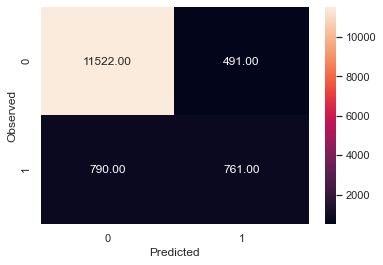

|  | Predict 0 | Predict 1 |
| --- | --- | --- |
| 0 | 11522 | 491 |
| 1 | 790 | 761 |

```python
df_cm = pd.DataFrame(confusion_matrix(BankData_DT_Y_test, bgcl_Y_predict), index = [i for i in ["0","1"]],
                  columns = [i for i in ["Predict 0","Predict 1"]])


draw_cm(BankData_DT_Y_test, bgcl_Y_predict)

df_cm
```

```python
print("***** Classification Report of Decision Tree***** ")
print(metrics.classification_report(BankData_Y_test, bgcl_Y_predict, labels=[1,0]))
```

```
***** Classification Report of Decision Tree*****
              precision    recall  f1-score   support

           1       0.61      0.49      0.54      1551
           0       0.94      0.96      0.95     12013

    accuracy                           0.91     13564
   macro avg       0.77      0.72      0.75     13564
weighted avg       0.90      0.91      0.90     13564
```

```python
precision_score(BankData_Y_test, bgcl_Y_predict)
```

```
0.6078274760383386
```

```python
recall_score(BankData_Y_test, bgcl_Y_predict)
```

```
0.49065119277885233
```

```python
f1_score(BankData_Y_test, bgcl_Y_predict)
```

```
0.5429896539422048
```

```python
roc_auc_score(BankData_Y_test, bgcl_Y_predict)
```

```
0.7248894022663928
```

```python
new_row = {'Model':'Bagging','Training Score':bgcl.score(BankData_DT_X_train , BankData_DT_Y_train),'Testing Score':bgcl.score(BankData_DT_X_test , BankData_DT_Y_test),'Precision Score':precision_score(BankData_Y_test, bgcl_Y_predict),'Recall Score':recall_score(BankData_Y_test, bgcl_Y_predict),'f1-Score':f1_score(BankData_Y_test, bgcl_Y_predict),'ROC_AUC_Score':roc_auc_score(BankData_Y_test, bgcl_Y_predict)}
df = df.append(new_row, ignore_index=True)
df
```

|  | Model | Training Score | Testing Score | Precision Score | Recall Score | f1-Score | ROC_AUC_Score |
| --- | --- | --- | --- | --- | --- | --- | --- |
| 0 | Logistic Regression | 0.902834 | 0.902389 | 0.632130 | 0.350097 | 0.450622 | 0.661896 |
| 1 | Decision Tree entropy | 0.899769 | 0.901430 | 0.627685 | 0.339136 | 0.440352 | 0.656582 |
| 2 | Decision Tree gini | 0.900528 | 0.901946 | 0.647530 | 0.312701 | 0.421739 | 0.645363 |
| 3 | Bagging | 0.999716 | 0.905559 | 0.607827 | 0.490651 | 0.542990 | 0.724889 |

## Ensemble Model - AdaBoosting

```python
from sklearn.ensemble import AdaBoostClassifier
# abcl = AdaBoostClassifier(n_estimators=10, random_state=1)
abcl = AdaBoostClassifier( n_estimators=50,random_state=1)
abcl = abcl.fit(BankData_DT_X_train, BankData_DT_Y_train)
```

## Scoring

```python
print(abcl.score(BankData_DT_X_train , BankData_DT_Y_train))
print(abcl.score(BankData_DT_X_test , BankData_DT_Y_test))
```

```
0.9014756533004709
0.9012828074314362
```

```python
print("Training accuracy = ",abcl.score(BankData_DT_X_train, BankData_DT_Y_train))  # this will give training accuracy as training data has been used
print()
print("Testing accuracy  = ",abcl.score(BankData_DT_X_test, BankData_DT_Y_test))   # this will give testing accuracy as testing data has been used
```

```
Training accuracy =  0.9014756533004709

Testing accuracy  =  0.9012828074314362
```

## Confusion Matrix

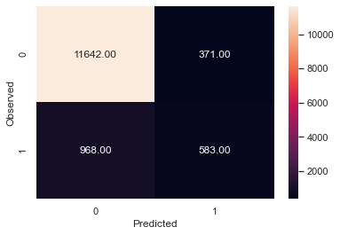

|  | Predict 0 | Predict 1 |
| --- | --- | --- |
| 0 | 11642 | 371 |
| 1 | 968 | 583 |

```python
abcl_Y_predict = abcl.predict(BankData_DT_X_test)

df_cm = pd.DataFrame(confusion_matrix(BankData_DT_Y_test, abcl_Y_predict), index = [i for i in ["0","1"]],
                  columns = [i for i in ["Predict 0","Predict 1"]])


draw_cm(BankData_DT_Y_test, abcl_Y_predict)

df_cm
```

```python
print("***** Classification Report of AdaBoosting ***** ")
print(metrics.classification_report(BankData_Y_test, abcl_Y_predict, labels=[1,0]))
```

```
***** Classification Report of AdaBoosting *****
              precision    recall  f1-score   support

           1       0.61      0.38      0.47      1551
           0       0.92      0.97      0.95     12013

    accuracy                           0.90     13564
   macro avg       0.77      0.67      0.71     13564
weighted avg       0.89      0.90      0.89     13564
```

```python
precision_score(BankData_Y_test, abcl_Y_predict)
```

```
0.6111111111111112
```

```python
recall_score(BankData_Y_test, abcl_Y_predict)
```

```
0.375886524822695
```

```python
f1_score(BankData_Y_test, abcl_Y_predict)
```

```
0.4654690618762475
```

```python
roc_auc_score(BankData_Y_test, abcl_Y_predict)
```

```
0.6725016574833528
```

```python
new_row = {'Model':'AdaBoosting','Training Score':abcl.score(BankData_DT_X_train , BankData_DT_Y_train),'Testing Score':abcl.score(BankData_DT_X_test , BankData_DT_Y_test),'Precision Score':precision_score(BankData_Y_test, abcl_Y_predict),'Recall Score':recall_score(BankData_Y_test, abcl_Y_predict),'f1-Score':f1_score(BankData_Y_test, abcl_Y_predict),'ROC_AUC_Score':roc_auc_score(BankData_Y_test, abcl_Y_predict)}
df = df.append(new_row, ignore_index=True)
df
```

|  | Model | Training Score | Testing Score | Precision Score | Recall Score | f1-Score | ROC_AUC_Score |
| --- | --- | --- | --- | --- | --- | --- | --- |
| 0 | Logistic Regression | 0.902834 | 0.902389 | 0.632130 | 0.350097 | 0.450622 | 0.661896 |
| 1 | Decision Tree entropy | 0.899769 | 0.901430 | 0.627685 | 0.339136 | 0.440352 | 0.656582 |
| 2 | Decision Tree gini | 0.900528 | 0.901946 | 0.647530 | 0.312701 | 0.421739 | 0.645363 |
| 3 | Bagging | 0.999716 | 0.905559 | 0.607827 | 0.490651 | 0.542990 | 0.724889 |
| 4 | AdaBoosting | 0.901476 | 0.901283 | 0.611111 | 0.375887 | 0.465469 | 0.672502 |

## Ensemble Model - GradientBoost

```python
from sklearn.ensemble import GradientBoostingClassifier
gbcl = GradientBoostingClassifier(n_estimators = 50,random_state=1)
gbcl = gbcl.fit(BankData_DT_X_train, BankData_DT_Y_train)
```

## Scoring

```python
print(gbcl.score(BankData_DT_X_train , BankData_DT_Y_train))
print(gbcl.score(BankData_DT_X_test , BankData_DT_Y_test))
```

```
0.9067842133535564
0.9051902093777646
```

```python
print("Training accuracy = ",gbcl.score(BankData_DT_X_train, BankData_DT_Y_train))  # this will give training accuracy as training data has been used
print()
print("Testing accuracy  = ",gbcl.score(BankData_DT_X_test, BankData_DT_Y_test))   # this will give testing accuracy as testing data has been used
```

```
Training accuracy =  0.9067842133535564

Testing accuracy  =  0.9051902093777646
```

## Confusion Matrix

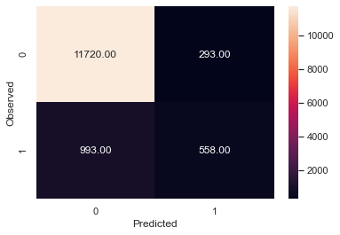

|  | Predict 0 | Predict 1 |
| --- | --- | --- |
| 0 | 11720 | 293 |
| 1 | 993 | 558 |

```python
gbcl_Y_predict = gbcl.predict(BankData_DT_X_test)

df_cm = pd.DataFrame(confusion_matrix(BankData_DT_Y_test, gbcl_Y_predict), index = [i for i in ["0","1"]],
                  columns = [i for i in ["Predict 0","Predict 1"]])


draw_cm(BankData_DT_Y_test, gbcl_Y_predict)

df_cm
```

```python
print("***** Classification Report of GradientBoost ***** ")
print(metrics.classification_report(BankData_Y_test, gbcl_Y_predict, labels=[1,0]))
```

```
***** Classification Report of GradientBoost *****
              precision    recall  f1-score   support

           1       0.66      0.36      0.46      1551
           0       0.92      0.98      0.95     12013

    accuracy                           0.91     13564
   macro avg       0.79      0.67      0.71     13564
weighted avg       0.89      0.91      0.89     13564
```

```python
precision_score(BankData_Y_test, gbcl_Y_predict)
```

```
0.6556991774383079
```

```python
recall_score(BankData_Y_test, gbcl_Y_predict)
```

```
0.3597678916827853
```

```python
f1_score(BankData_Y_test, gbcl_Y_predict)
```

```
0.46461282264779347
```

```python
roc_auc_score(BankData_Y_test, gbcl_Y_predict)
```

```
0.6676888238901731
```

```python
new_row = {'Model':'GradientBoost','Training Score':gbcl.score(BankData_DT_X_train , BankData_DT_Y_train),'Testing Score':gbcl.score(BankData_DT_X_test , BankData_DT_Y_test),'Precision Score':precision_score(BankData_Y_test, gbcl_Y_predict),'Recall Score':recall_score(BankData_Y_test, gbcl_Y_predict),'f1-Score':f1_score(BankData_Y_test, gbcl_Y_predict),'ROC_AUC_Score':roc_auc_score(BankData_Y_test, gbcl_Y_predict)}
df = df.append(new_row, ignore_index=True)
df
```

|  | Model | Training Score | Testing Score | Precision Score | Recall Score | f1-Score | ROC_AUC_Score |
| --- | --- | --- | --- | --- | --- | --- | --- |
| 0 | Logistic Regression | 0.902834 | 0.902389 | 0.632130 | 0.350097 | 0.450622 | 0.661896 |
| 1 | Decision Tree entropy | 0.899769 | 0.901430 | 0.627685 | 0.339136 | 0.440352 | 0.656582 |
| 2 | Decision Tree gini | 0.900528 | 0.901946 | 0.647530 | 0.312701 | 0.421739 | 0.645363 |
| 3 | Bagging | 0.999716 | 0.905559 | 0.607827 | 0.490651 | 0.542990 | 0.724889 |
| 4 | AdaBoosting | 0.901476 | 0.901283 | 0.611111 | 0.375887 | 0.465469 | 0.672502 |
| 5 | GradientBoost | 0.906784 | 0.905190 | 0.655699 | 0.359768 | 0.464613 | 0.667689 |

## Ensemble Model - RandomForest

```python
from sklearn.ensemble import RandomForestClassifier
rfcl = RandomForestClassifier(n_estimators = 50, random_state=1,max_features=12)
rfcl = rfcl.fit(BankData_DT_X_train, BankData_DT_Y_train)
```

```python
rfcl_Y_predict = rfcl.predict(BankData_DT_X_test)

print(rfcl.score(BankData_DT_X_train, BankData_DT_Y_train))
print(rfcl.score(BankData_DT_X_test, BankData_DT_Y_test))
```

```
0.9998420071412772
0.9048953111176644
```

```python
print("Training accuracy = ",rfcl.score(BankData_DT_X_train, BankData_DT_Y_train))  # this will give training accuracy as training data has been used
print()
print("Testing accuracy  = ",rfcl.score(BankData_DT_X_test, BankData_DT_Y_test))   # this will give testing accuracy as testing data has been used
```

```
Training accuracy =  0.9998420071412772

Testing accuracy  =  0.9048953111176644
```

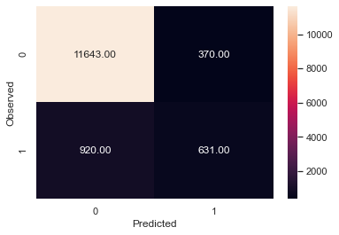

|  | Predict 0 | Predict 1 |
| --- | --- | --- |
| 0 | 11643 | 370 |
| 1 | 920 | 631 |

```python
rfcl_Y_predict = rfcl.predict(BankData_DT_X_test)

df_cm = pd.DataFrame(confusion_matrix(BankData_DT_Y_test, rfcl_Y_predict), index = [i for i in ["0","1"]],
                  columns = [i for i in ["Predict 0","Predict 1"]])


draw_cm(BankData_DT_Y_test, rfcl_Y_predict)

df_cm
```

```python
print("***** Classification Report of RandomForest ***** ")
print(metrics.classification_report(BankData_Y_test, rfcl_Y_predict, labels=[1,0]))
```

```
***** Classification Report of RandomForest *****
              precision    recall  f1-score   support

           1       0.63      0.41      0.49      1551
           0       0.93      0.97      0.95     12013

    accuracy                           0.90     13564
   macro avg       0.78      0.69      0.72     13564
weighted avg       0.89      0.90      0.90     13564
```

```python
precision_score(BankData_Y_test, rfcl_Y_predict)
```

```
0.6303696303696303
```

```python
recall_score(BankData_Y_test, rfcl_Y_predict)
```

```
0.40683430045132174
```

```python
f1_score(BankData_Y_test, rfcl_Y_predict)
```

```
0.494514106583072
```

```python
roc_auc_score(BankData_Y_test, gbcl_Y_predict)
```

```
0.6676888238901731
```

```python
new_row = {'Model':'Random Forest','Training Score':rfcl.score(BankData_DT_X_train , BankData_DT_Y_train),'Testing Score':rfcl.score(BankData_DT_X_test , BankData_DT_Y_test),'Precision Score':precision_score(BankData_Y_test, rfcl_Y_predict),'Recall Score':recall_score(BankData_Y_test, rfcl_Y_predict),'f1-Score':f1_score(BankData_Y_test, rfcl_Y_predict),'ROC_AUC_Score':roc_auc_score(BankData_Y_test, rfcl_Y_predict)}
df = df.append(new_row, ignore_index=True)
df
```

[output not shown]

## DataFrame with model comparisons

```python
# df is the Dataframe created to append all the different models
df
```

|  | Model | Training Score | Testing Score | Precision Score | Recall Score | f1-Score | ROC_AUC_Score |
| --- | --- | --- | --- | --- | --- | --- | --- |
| 0 | Logistic Regression | 0.902834 | 0.902389 | 0.632130 | 0.350097 | 0.450622 | 0.661896 |
| 1 | Decision Tree entropy | 0.899769 | 0.901430 | 0.627685 | 0.339136 | 0.440352 | 0.656582 |
| 2 | Decision Tree gini | 0.900528 | 0.901946 | 0.647530 | 0.312701 | 0.421739 | 0.645363 |
| 3 | Bagging | 0.999716 | 0.905559 | 0.607827 | 0.490651 | 0.542990 | 0.724889 |
| 4 | AdaBoosting | 0.901476 | 0.901283 | 0.611111 | 0.375887 | 0.465469 | 0.672502 |
| 5 | GradientBoost | 0.906784 | 0.905190 | 0.655699 | 0.359768 | 0.464613 | 0.667689 |
| 6 | Random Forest | 0.999842 | 0.904895 | 0.630370 | 0.406834 | 0.494514 | 0.688017 |
| 7 | Random Forest | 0.999842 | 0.904895 | 0.630370 | 0.406834 | 0.494514 | 0.688017 |

### Both Logistic regression and Decision trees are used for classification purpose such as

Logistic Regression Advantage:- Logistic regression is designed for classification, and is most useful for understanding the influence of several independent variables on a single outcome variable.

Logistic Regression Disadvantage:-

- Works only when the predicted variable is binary, assumes all predictors are independent of- -each other, and assumes data is free of missing values.

DT Advantage:- Decision Tree is simple to understand and visualise, requires little data preparation, and can- -handle both numerical and categorical data.

DT DisAdvantage:- Decision tree can create complex trees that do not generalise well, and decision trees can be- -unstable because small variations in the data might result in a completely different tree being generated.

```
Below are two basic functions of Decision trees and Logistic regression.
A. Decision Tree
    a. Selecting the best attribute/feature to divide a set at each branch, and
    b. Deciding whether each branch is justified adequately.
    The different decision-tree programs differ in how these are accomplished.

B. Logistic Regression
    a. Stepwise selections of the variables and the corresponding coefficients computed
    b. The maximum-likelihood ratio is used to determine the statistical significance of
    the variables which will be part of the Logistic Regression equation.
```

```python
#Ensemble Techniques - Bagging, AdaBoosting,GradientBoost, Randomforest.

# After compare all the ensemble model performance with the base model is almost equal but improved in
#bagging ensemble technique





#AdaBoosting done with DT
#   -(with n_estimator = 10 )- performance went down precision from .63 to .57, accuracy from 90% to 89%
#   -(with n_estimator =50) - performance values are similar to base model.
#AdaBoosting done with Logistic Regression
#   -(with n_estimator = 10 ) - performance went down as compared to DT f1 score turned .11
#   -(with n_estimator =50) - f1 score .31 and accuracy 90%.
#Gradient Boost done with DT  - Performance slightly improved from 90% to 91%
# for Random forest default is DT - Recall(from .34 to .41) and f1 score (from .44 to .49) slighlty improved.
```